# Visualization

## Pitfalls of Color Use

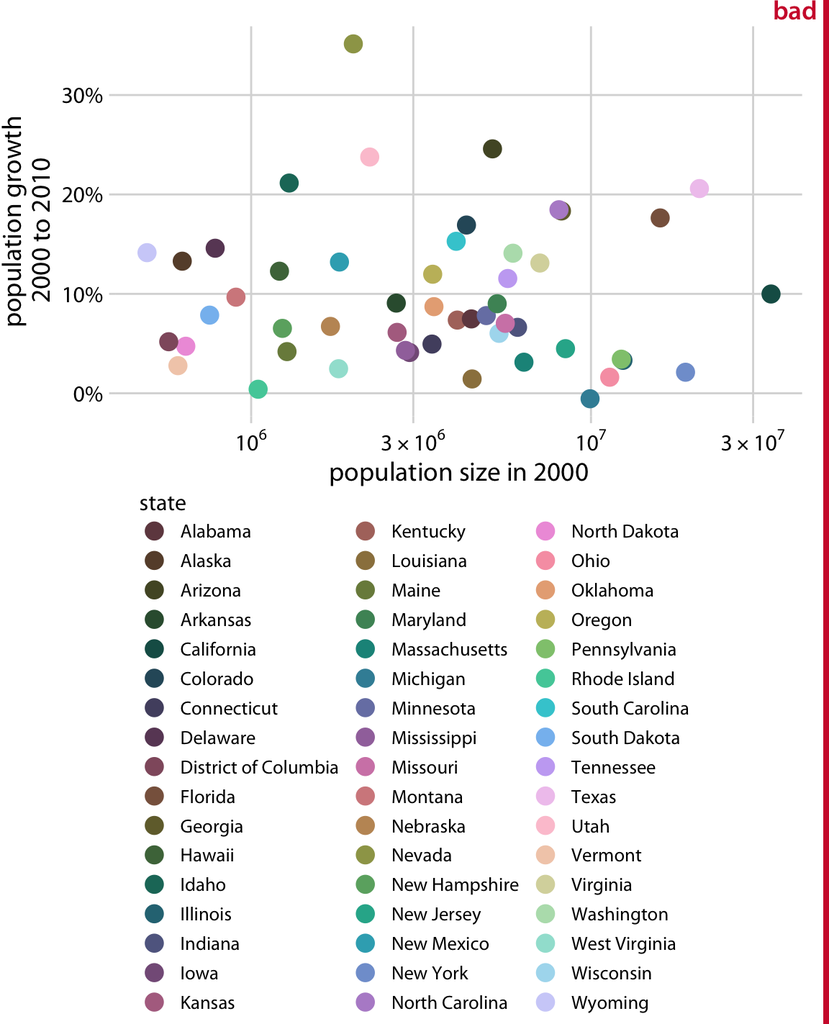

## Pitfalls of Color Use

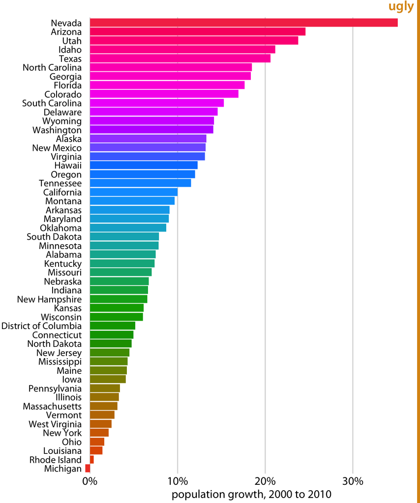

## Pitfalls of Color Use

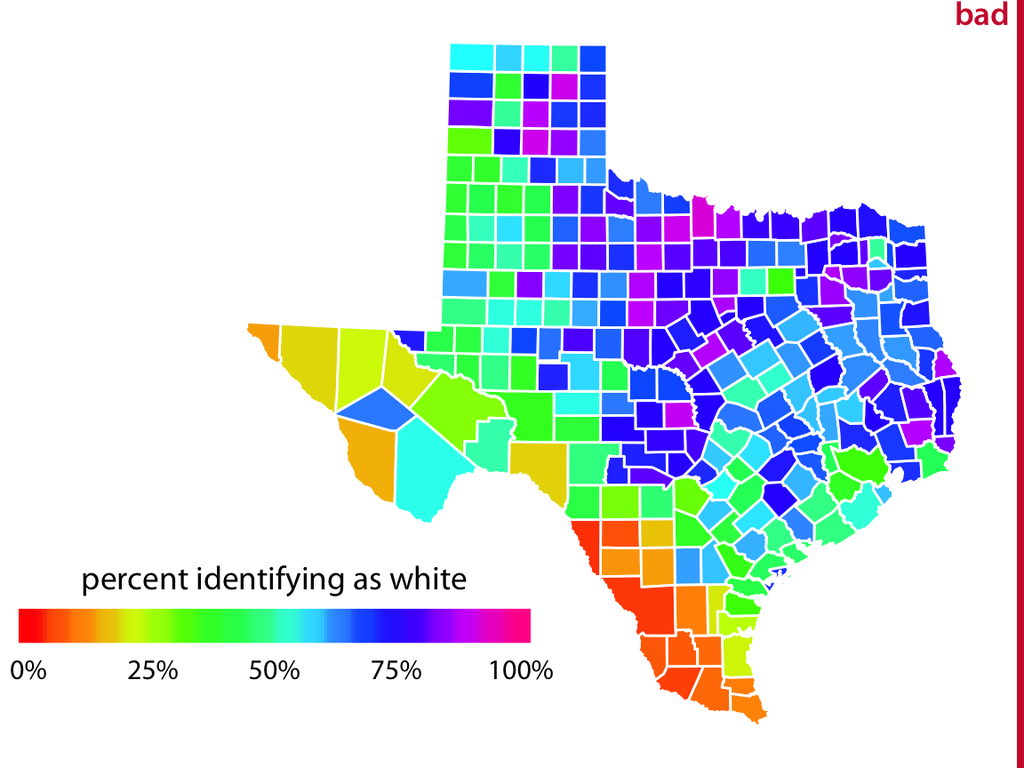

## Color palettes

Choose the color palette that is most appropriate for your data:

- *Qualitative:* Designed for coding categorical information, i.e., where no particular ordering of categories is available
- *Sequential:* Designed for coding ordered/numeric information, i.e., where colors go from high to low (or vice versa)
- *Diverging:* Designed for coding ordered/numeric information around a central neutral value, i.e., where colors diverge from neutral to two extremes.

See: https://cran.r-project.org/web/packages/colorspace/vignettes/colorspace.html

## RGB manipulation

We can build a sequential palette ourselves by systematically changing the numerical value of a base color. Colors are just numbers.

```r
#| output-location: slide

base <- "#1B9E77"


light_seq <- lighten(base, amount = seq(0.6, 0.1, length.out = 3))

dark_seq  <- darken(base,  amount = seq(0.1, 0.6, length.out = 3))


seq_pal <- c(light_seq, base, dark_seq)

seq_pal
```

```
[1] "#7CE3BB" "#5AC59E" "#32A982" "#1B9E77" "#0E8E6A" "#00664A" "#03402E"
```

```r
ggplot() +

  geom_point(aes(x = seq_along(seq_pal), y = seq_along(seq_pal)),

             color = seq_pal, size = 10) +

  theme_minimal(base_size = 16)
```

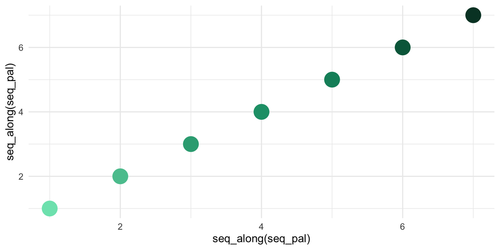

The Okabe–Ito palette is a well-tested qualitative alternative to the defaults:

```r
Okabe_Ito <- c("#000000", "#E69F00", "#56B4E9", "#009E73",

               "#F0E442", "#0072B2", "#D55E00", "#CC79A7")
```

It was designed to stay distinguishable for viewers with color vision deficiency.

## Sequential colors

```r
africa_data |> select(parliament_pct_women) |>
ggplot() +
    geom_sf(aes(fill = parliament_pct_women)) +
    colorspace::scale_fill_continuous_sequential() +
  theme_void()
```

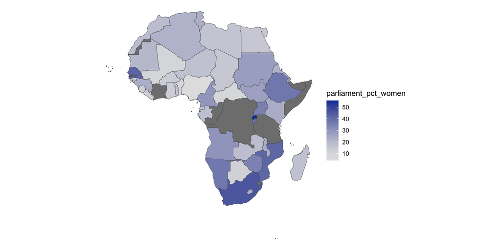

## Diverging colors

```r
africa_data <- africa_data |>
  mutate(across(starts_with("pop_"), \(x) x/total_pop, .names = "{.col}_pct")) |>
  mutate(pct_under_15 = 1 - pop_15to64_pct - pop_over65_pct)
africa_data |>
  ggplot() +
    geom_sf(aes(fill = pct_under_15)) +
    colorspace::scale_fill_continuous_diverging(mid=median(africa_data$pct_under_15, na.rm=TRUE), palette="Blue-Red 3") +
  theme_void()
```

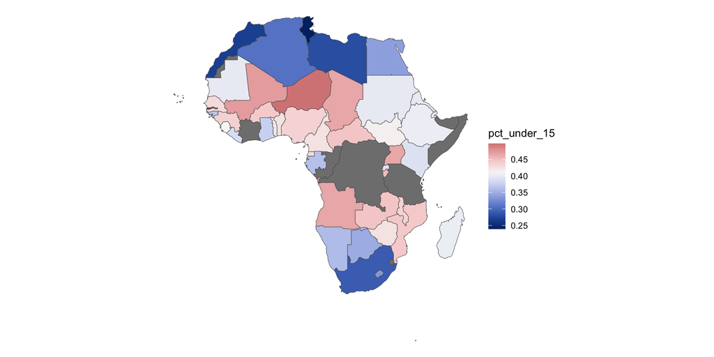

# Composing and comparing plots

## Patchwork

```r
library(patchwork)
pop_boxplot + pop_histogram
```

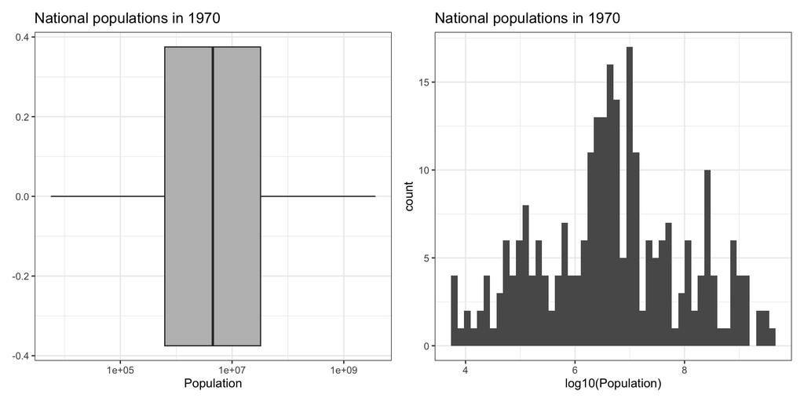

## Patchwork

```r
pop_boxplot / pop_histogram
```

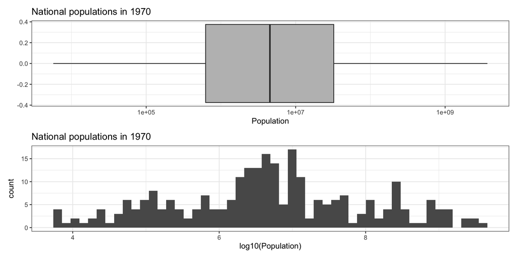

## Faceting

```r
  gdp2 |>
  mutate(year = ymd(paste0(year, "-01-01"))) |>
  filter(`Country Name` %in% c("Italy", "France", "Germany", "Spain")) |>
  ggplot() + geom_line(aes(x=year, y=GDP)) +
  facet_wrap(~`Country Name`)
```

## Faceting

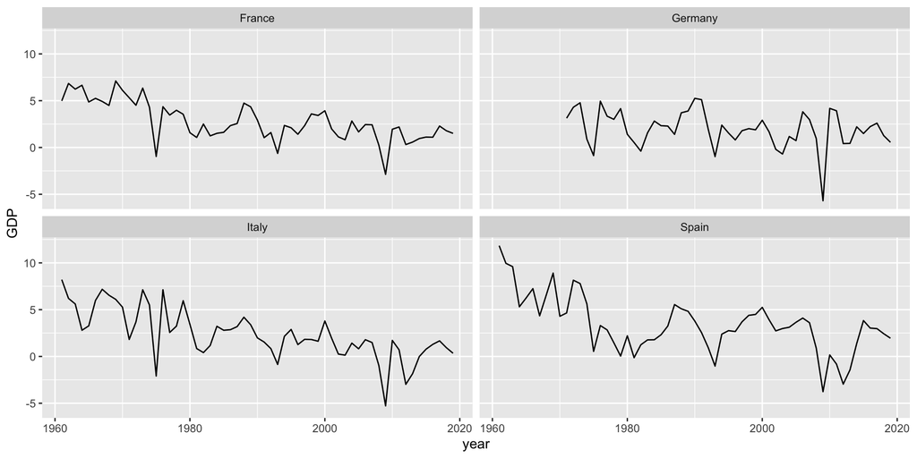

## GDP

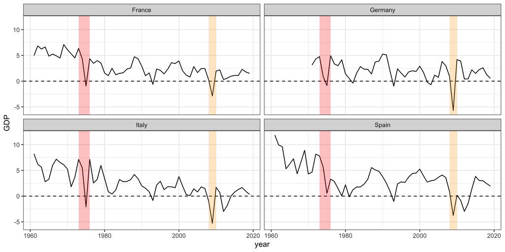

## GDP

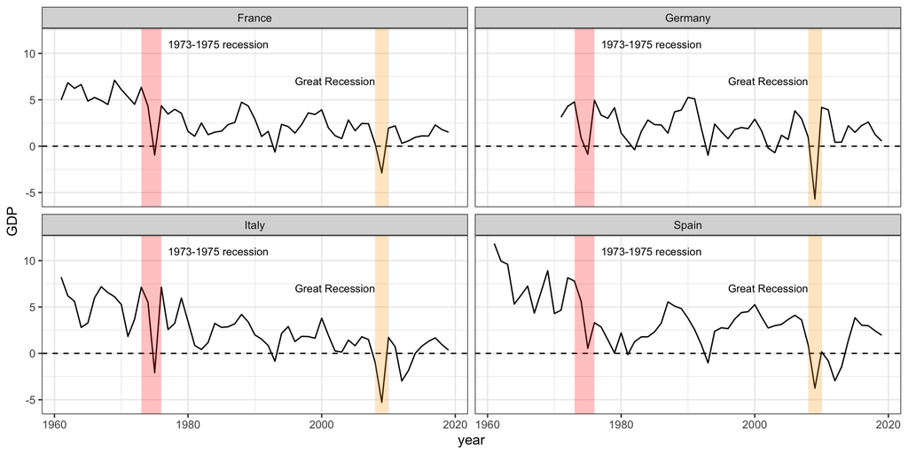

## Faceting

```r
ggplot(mpg, aes(displ, hwy)) +
  geom_point() +
  facet_wrap(vars(cyl, drv))
```

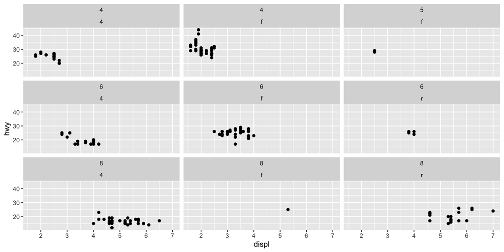

## Principle of Proportional Ink

> **The principle of proportional ink:** The sizes of shaded areas in a visualization need to be proportional to the data values they represent.

## Redundant Coding

The plot below shows sepal width versus sepal length for three iris species.

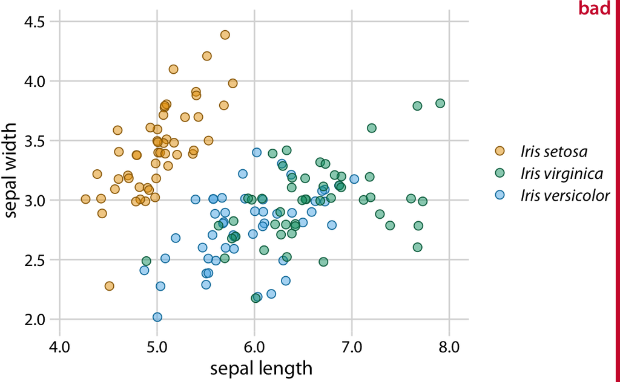

Why is this plot labeled *bad* (but not *ugly*)?

The points for *Iris virginica* and *Iris versicolor* intermingle.

## Redundant Coding

Two fixes:

- swap the colors used for *Iris setosa* and *Iris versicolor*;
- use three different symbol **shapes**, so the points differ along two dimensions.

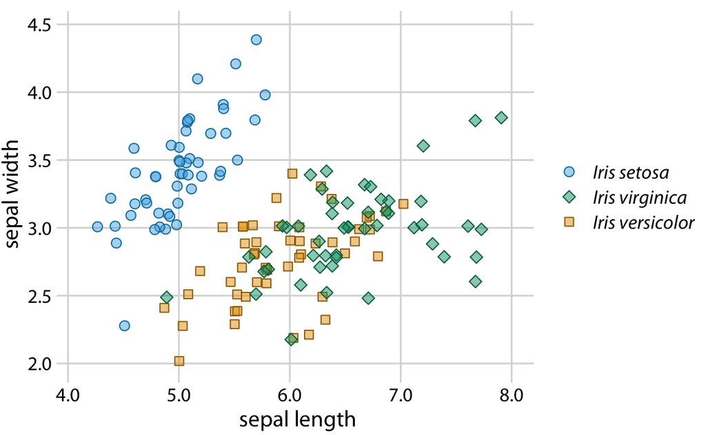

## Redundant Coding

> **Redundant coding:** a design principle that uses multiple aesthetic dimensions to encode the same data.
- Small colored objects can be hard to distinguish
- Colors may look similar to viewers with color vision deficiency

Usually a combination of color + shape, or color + point size.

## Order your legend to match your data

Why is this one bad?

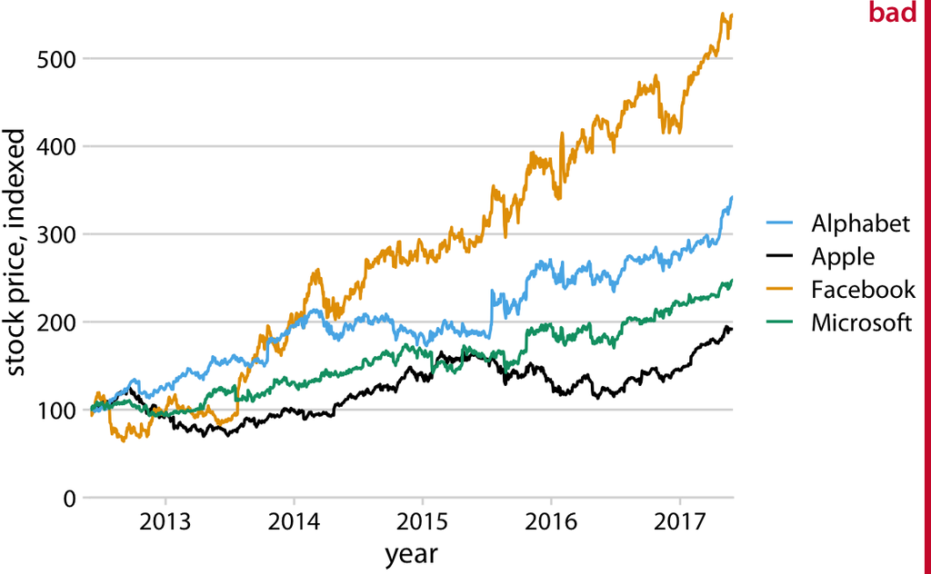

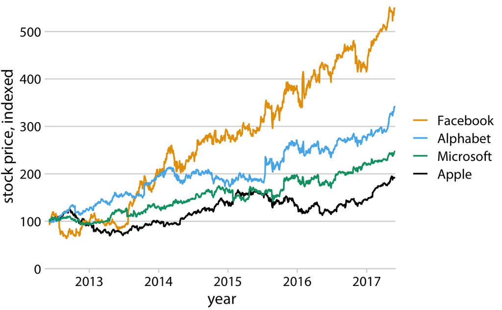

Match the order of the legend to the order of the curves, not the alphabet.

# Visualization for exploration

> The greatest value of a picture is when it forces us to notice what we never expected to see.

> — John Tukey

## Diamonds data

```
Rows: 53,940
Columns: 10
$ carat   <dbl> 0.23, 0.21, 0.23, 0.29, 0.31, 0.24, 0.24, 0.26, 0.22, 0.23, 0.…
$ cut     <ord> Ideal, Premium, Good, Premium, Good, Very Good, Very Good, Ver…
$ color   <ord> E, E, E, I, J, J, I, H, E, H, J, J, F, J, E, E, I, J, J, J, I,…
$ clarity <ord> SI2, SI1, VS1, VS2, SI2, VVS2, VVS1, SI1, VS2, VS1, SI1, VS1, …
$ depth   <dbl> 61.5, 59.8, 56.9, 62.4, 63.3, 62.8, 62.3, 61.9, 65.1, 59.4, 64…
$ table   <dbl> 55, 61, 65, 58, 58, 57, 57, 55, 61, 61, 55, 56, 61, 54, 62, 58…
$ price   <int> 326, 326, 327, 334, 335, 336, 336, 337, 337, 338, 339, 340, 34…
$ x       <dbl> 3.95, 3.89, 4.05, 4.20, 4.34, 3.94, 3.95, 4.07, 3.87, 4.00, 4.…
$ y       <dbl> 3.98, 3.84, 4.07, 4.23, 4.35, 3.96, 3.98, 4.11, 3.78, 4.05, 4.…
$ z       <dbl> 2.43, 2.31, 2.31, 2.63, 2.75, 2.48, 2.47, 2.53, 2.49, 2.39, 2.…
```

## Diamonds data

Consider the relationship between the length and width of diamonds:

```r
data("diamonds")
ggplot(diamonds, aes(x = x, y = y)) +
  geom_point()+
  theme_bw()
```

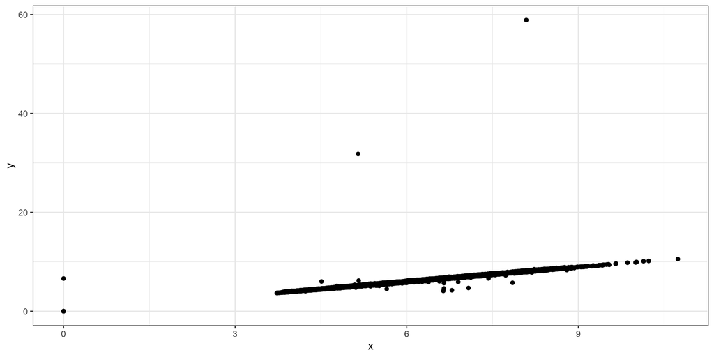

What do you notice? What can be done?

## Naming the outliers

Labelling the extreme points tells us *which* values are the problem:

```r
ggplot(diamonds, aes(x = x, y = y)) +
  geom_point() +
  geom_text(data = subset(diamonds, x < 3), aes(label = x), nudge_y = 2) +
  geom_text(data = subset(diamonds, y > 30), aes(label = y), nudge_y = 2) +
  theme_bw()
```

## Naming the outliers

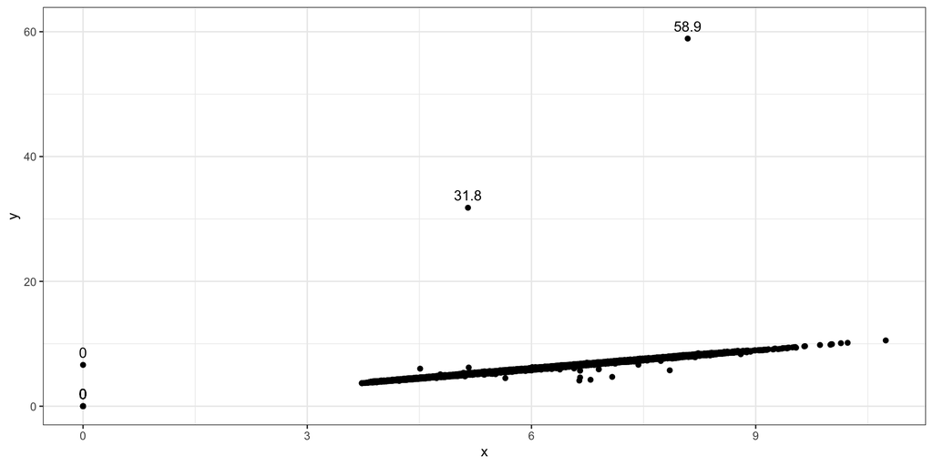

## Outliers and artifacts

```r
diamonds %>%
 filter(y <= 30, x >= 3) %>%
ggplot(aes(x = x, y = y)) +
  geom_point(size=0.1) + theme_bw()
```

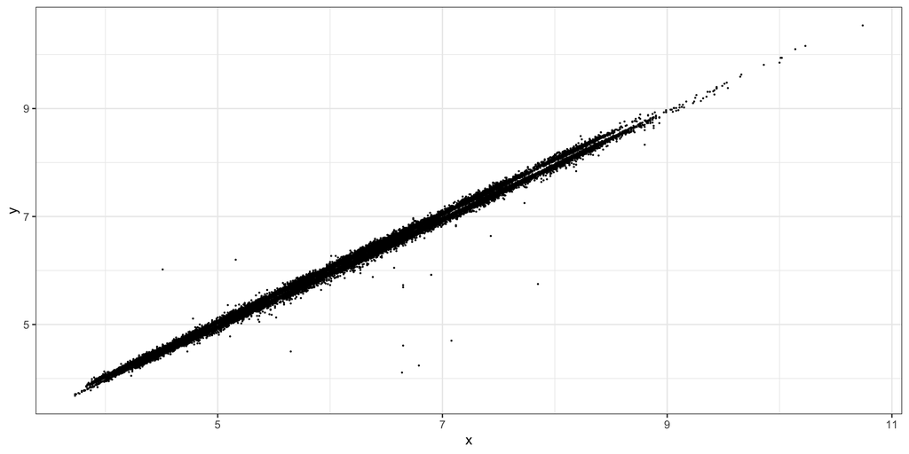

Zooming in and excluding the outliers reveals the underlying relationship much more clearly.

## Handling outliers

- Best to **pre-specify your criteria** for excluding outliers before the analysis
- Show results **with and without** outliers removed. Clearly state:
  - how many observations were excluded (here, 10 of 53,940)
  - the method used for detection
  - how the results differ between the two analyses

## Outliers and artifacts

What about the relationship between length and price?

```r
diamonds %>%
 filter(y <= 30, x >= 3) %>%
ggplot(aes(x = x, y = price)) +
  geom_point() + theme_bw()
```

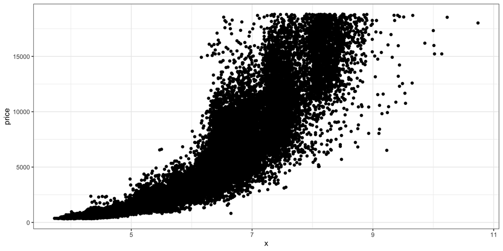

We have so many points that *overplotting* becomes an issue.

## Overplotting

```r
diamonds %>%
 filter(y <= 30, x >= 3) %>%
ggplot(aes(x = x, y = price)) +
  geom_hex(bins=100) + theme_bw() +
  colorspace::scale_fill_binned_sequential(palette = "BurgYl", n.breaks=10)
```

## Overplotting

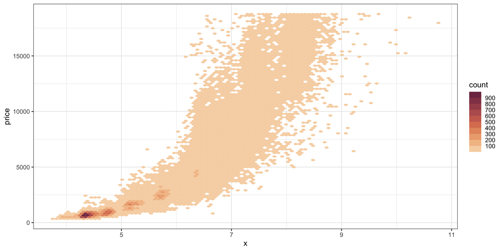

## Overplotting

As an alternative, let’s reduce the point size

```r
diamonds %>%
 filter(y <= 30, x >= 3) %>%
ggplot(aes(x = x, y = price, col=cut)) +
  geom_point(size=0.1) + theme_bw()
```

## Overplotting

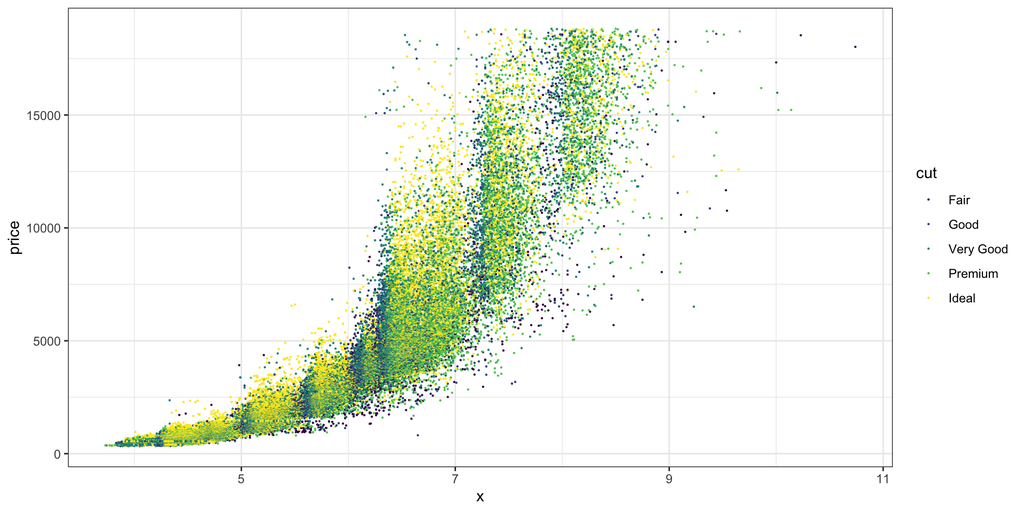

## Overplotting

Let’s reduce the point size even more and add opacity:

```r
diamonds %>%
 filter(y <= 30, x >= 3) %>%
ggplot(aes(x = x, y = price)) +
  geom_point(size=0.01, alpha=0.2) + theme_bw()
```

## Overplotting

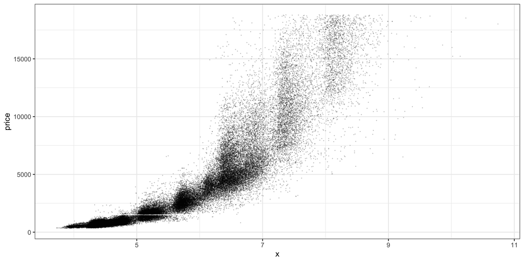

## Outliers and artifacts

Let’s look at just the diamond length:

```r
diamonds |> ggplot(aes(x=x)) + geom_histogram()
```

## Outliers and artifacts

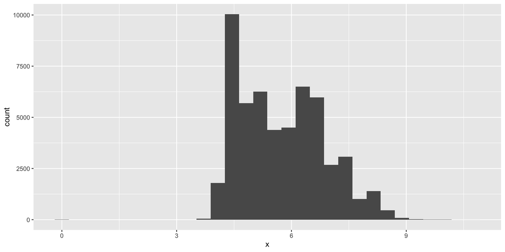

## Outliers and artifacts

A smaller binwidth reveals more structure.

```r
diamonds |> ggplot(aes(x=x)) + geom_histogram(binwidth=0.1)
```

## Outliers and artifacts

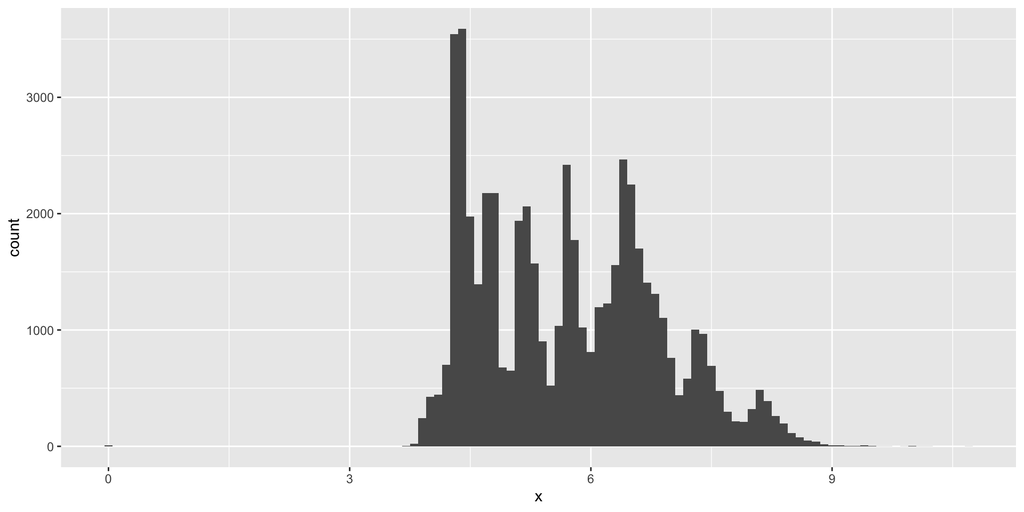

## Outliers and artifacts

What about price?

```r
diamonds |> ggplot(aes(x=price)) +
  geom_histogram(binwidth=100)
```

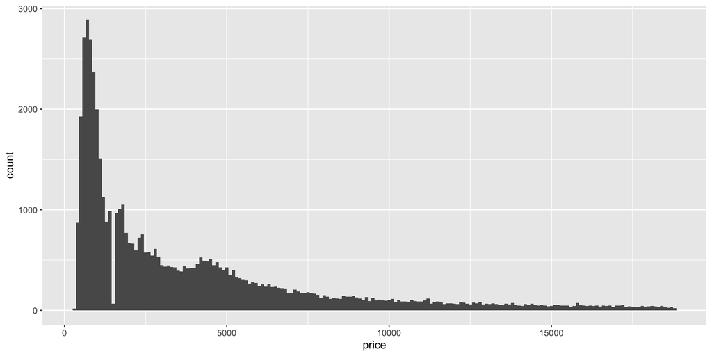

## Anomalies

Zooming in, there are *no diamonds at all* priced at $1500?

```r
diamonds |> ggplot(aes(x=price)) +
  geom_histogram(binwidth=25) + xlim(c(0, 2500))
```

## Anomalies

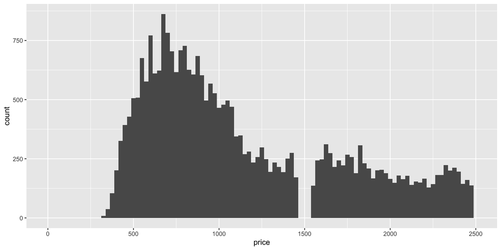

## Anomalies

Buried in a reddit thread:

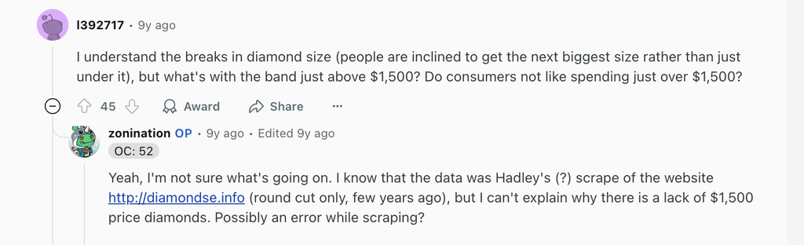

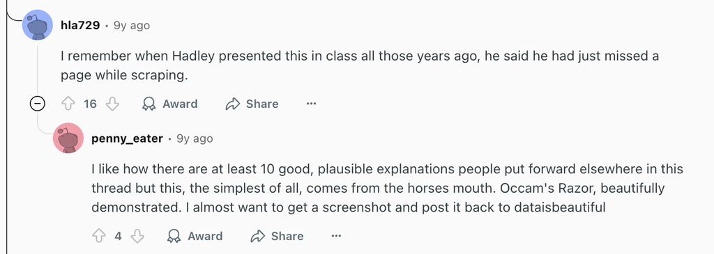

Many plausible theories but the answer was a missed page while scraping. **Occam’s razor:** assume the simplest explanation (e.g a mistake in the data) before you investigate more complex explanations.

## Outliers and artifacts

```r
diamonds |> ggplot() +
  geom_point(aes(x=carat, y=price), size=0.1) +
  theme_bw()
```

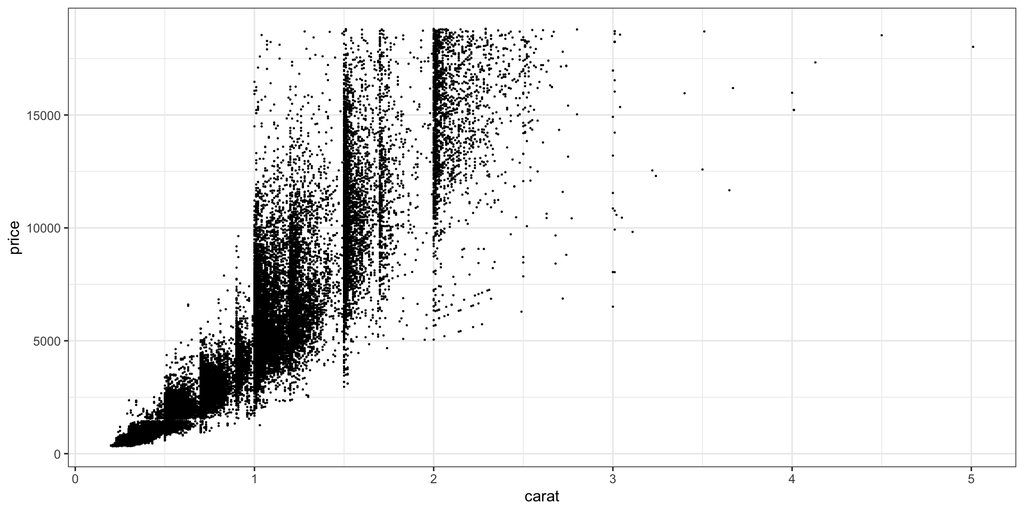

## Outliers and artifacts

```r
diamonds |> ggplot() + geom_point(aes(x=x, y=carat))
```

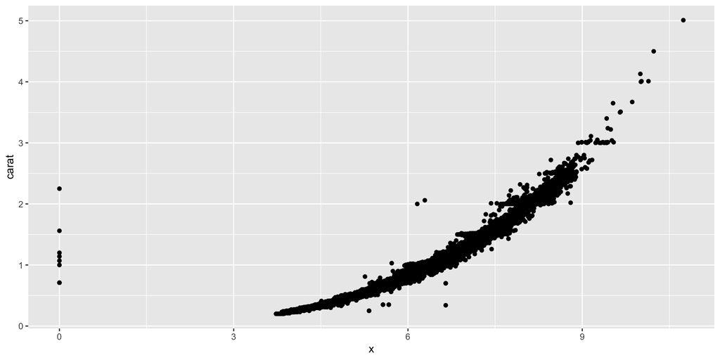

## Concepts covered in the diamonds data

- **Outliers.** `x = 0` is physically impossible.
- **Overplotting.** With 50,000 observations a scatterplot turns into a solid blob. Hex bins, smaller points, and opacity each reveal different structure.
- **Resolution.** The default histogram of length hid important structure. Making the binwidth smaller exposed clusters.
- **Artifacts and anomalies.** The missing $1,500 diamonds are a property of how the data were collected (or weren’t collected!) not a property of diamonds themselves.
- **Clustering and hidden variables.** Carat vs price falls into vertical bands. Buyers round up.
- **Occam’s razor.** The simplest explanation is usually the best.

## Billboard Data

Let’s return to the billboard dataset

```r
billboard_long <- billboard |>
  pivot_longer(cols = starts_with("wk"),
               names_to = "week",
               names_prefix = "wk",
               names_transform = list(week = as.integer),
               values_to = "rank")
billboard_long
```

```
# A tibble: 24,092 × 5
   artist track                   date.entered  week  rank
   <chr>  <chr>                   <date>       <int> <dbl>
 1 2 Pac  Baby Don't Cry (Keep... 2000-02-26       1    87
 2 2 Pac  Baby Don't Cry (Keep... 2000-02-26       2    82
 3 2 Pac  Baby Don't Cry (Keep... 2000-02-26       3    72
 4 2 Pac  Baby Don't Cry (Keep... 2000-02-26       4    77
 5 2 Pac  Baby Don't Cry (Keep... 2000-02-26       5    87
 6 2 Pac  Baby Don't Cry (Keep... 2000-02-26       6    94
 7 2 Pac  Baby Don't Cry (Keep... 2000-02-26       7    99
 8 2 Pac  Baby Don't Cry (Keep... 2000-02-26       8    NA
 9 2 Pac  Baby Don't Cry (Keep... 2000-02-26       9    NA
10 2 Pac  Baby Don't Cry (Keep... 2000-02-26      10    NA
# ℹ 24,082 more rows
```

## Exploring song rank

Let’s plot the change in song rank for the songs by 3 artists by week:

```r
billboard_long |>
  filter(artist %in% c("Jay-Z", "Houston, Whitney", "Aguilera, Christina")) |>
  drop_na() |>
  ggplot() + geom_line(aes(x=week, y=rank, col=artist, group=track)) +
  theme_bw(base_size=16)
```

## Exploring song rank

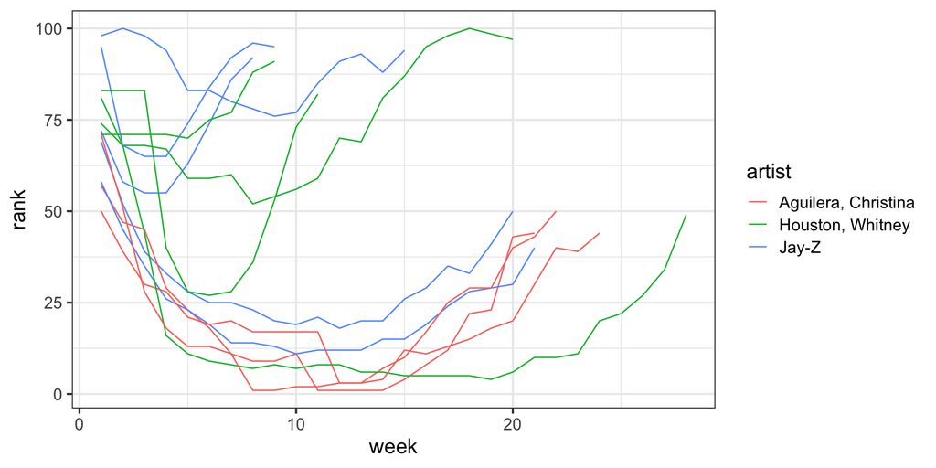

## Exploring song rank

Create a new column which is the actual date the song achieved that rank:

```r
billboard_long |>
  filter(artist %in% c("Jay-Z", "Aguilera, Christina", "Houston, Whitney")) |>
  drop_na() |>
  mutate(date = date.entered + weeks(week)) |>
  ggplot() + geom_line(aes(x=date, y=rank, col=artist, group=track)) +
  theme_bw(base_size=16)
```

## Exploring song rank

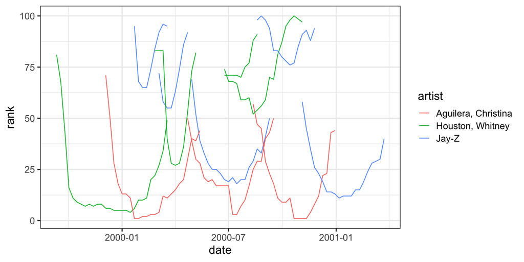

## Exploring Missingness

There is a lot of missingness. What patterns can we identify?

```r
billboard_long |>
  group_by(week) |>
  summarize(frac_missing = mean(is.na(rank))) |>
  ggplot() + geom_line(aes(x=week, y=frac_missing)) +
  theme_bw(base_size=16) +
  xlab("Weeks since entering top 100") + ylab("Fraction missing")
```

What does “fraction missing correspond to”?

## Exploring Missingness

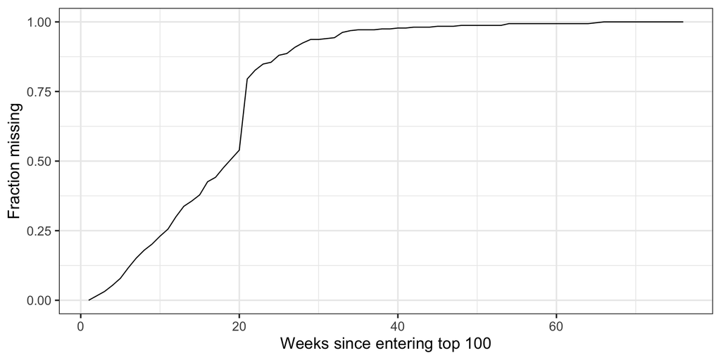

## Exploring Missingness

```r
billboard_long |>
  group_by(week) |>
  summarize(frac_missing = mean(is.na(rank))) |>
  ggplot() + geom_line(aes(x=week, y=frac_missing)) +
  theme_bw(base_size=16) +
  xlab("Weeks on top 100") + ylab("Percent of Songs")
```

What do you notice?

## Exploring Missingness

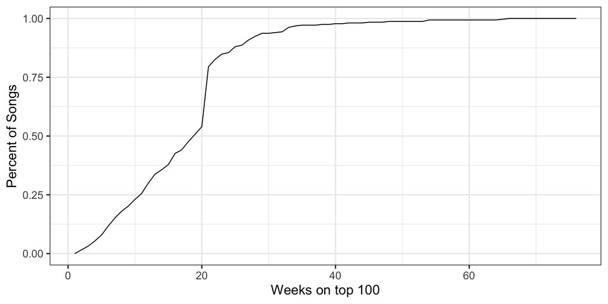

## The Recurrent Rule

> If a song has been on the Hot 100 chart for 20 weeks and is not currently inside the top 50 (or lacks strong upward momentum), Billboard automatically removes it from the chart, to prevent long-running hits from stagnating the rankings and blocking new entries.

## Concepts covered in the billboard data

- **Tidying helps plotting.** `wk1...wk76` are values of a variable, not 76 variables.
- **Color vs. grouping.** Jay-Z has five songs and without the grouping they get drawn as one line. Set `col = artist` and `group = track` to see all of them.
- **Choices for the x-axis.** Weeks-since-entering vs. calendar date answer different questions about the same data.
- **Missingness is data.** The fraction of missing values at each week has meaning in the context of the Billboard chart.

## Comparing data across groups

What’s the best way to compare data across multiple groups?

- Same plot? Different plot?
- Absolute vs relative?
- `patchwork` and `facet_wrap` as tools

## Planned Parenthood Example

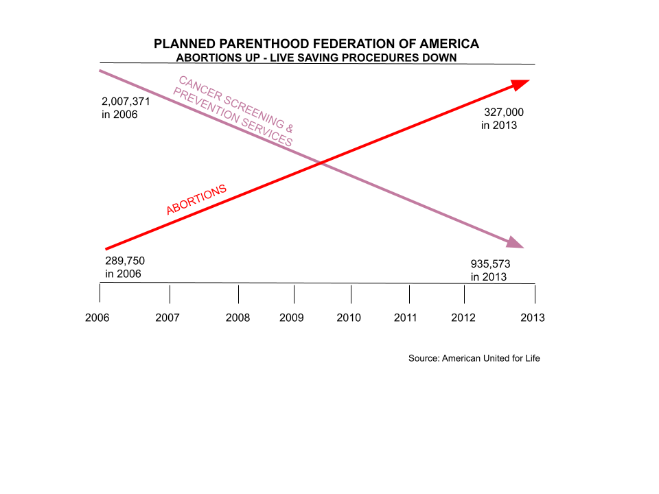

## Planned parenthood services

```r
cancer_plot <- pp_data |> ggplot() + geom_line(aes(x=year, y=cancerscreen)) + theme_bw()
abortion_plot <- pp_data |> ggplot() + geom_line(aes(x=year, y=abortions)) + theme_bw()

## Plot them side by side
cancer_plot + abortion_plot
```

## Planned parenthood services

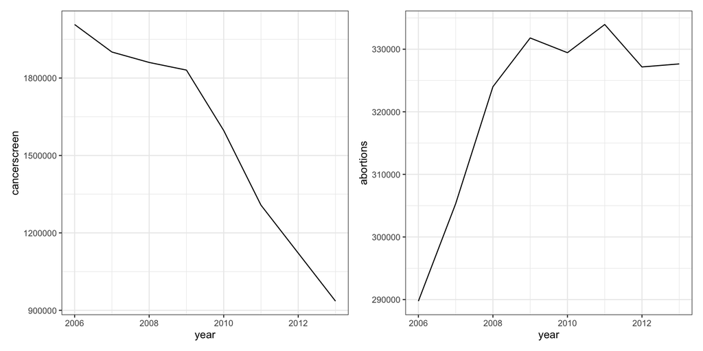

## On the same plot

```r
pp_data |> ggplot() +
  geom_line(aes(x=year, y=cancerscreen), col="blue") +
  geom_line(aes(x=year, y=abortions), col="red") +
  ylab("") +
  theme_bw()
```

## On the same plot

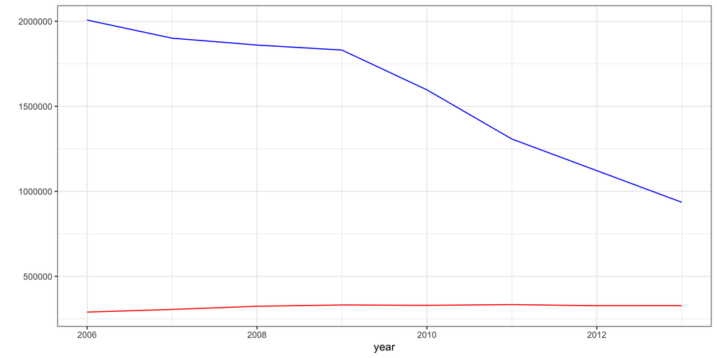

## Absolute vs relative levels

Absolute levels:

```r
pop |>
  filter(`Country Name` %in% c("Oman", "United States")) |>
  ggplot() + geom_line(aes(x=Year, y=Population, col=`Country Name`)) +
  theme_bw(base_size=16)
```

## Absolute vs relative levels

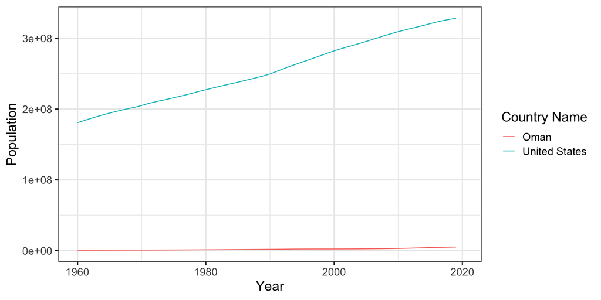

## Absolute vs relative levels

Relative levels:

```r
pop |>
  group_by(`Country Name`) |>
  mutate(`Relative Population Change` = Population / first(Population[Year=="1960-01-01"])) |>
  filter(`Country Name` %in% c("Oman", "United States")) |>
  ggplot() + geom_line(aes(x=Year, y=`Relative Population Change`, col=`Country Name`)) +
  theme_bw(base_size=16) +
  scale_y_continuous(breaks=1:10)
```

## Absolute vs relative levels

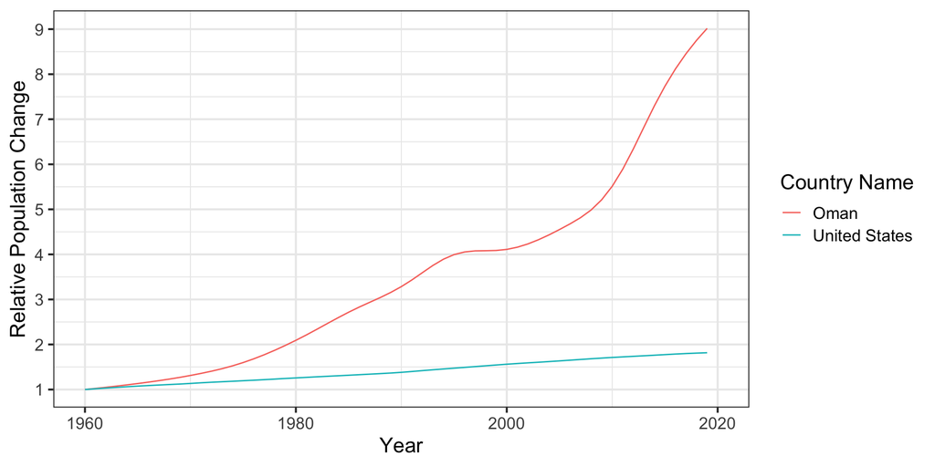

## Workflow tips and advice

Developing a graphic is iterative trial and error. A reasonable loop:

- **Start with a question.** e.g. “Does the gender gap shrink with income?”, not “let’s make a bar chart.”
- **Make the crudest version first.** Default geom, default theme, no labels. You are only asking whether there is anything there at all.
- **Change one thing at a time.**
- **Ask new questions based on what you see in the plots.** Most of what we saw today came from reacting to something we saw in a plot, not from a pre-specified plan.

## Some additional tips

| Symptom | Things to try |
| --- | --- |
| Solid blob of points | smaller points, `alpha`, `geom_hex()` |
| A few outlier points ruin the scale | set a rule for removing and report what you dropped |
| Distribution looks featureless | change `binwidth`, zoom in |
| Too many lines or colors | facet, or gray out everything but the ones you mean |
| Groups on wildly different scales | plot relative change instead of absolute |
| Two panels you can’t compare | one shared axis instead of `patchwork` |
| Reader can’t find the point | say it in the title and provide a label directly instead of a legend |